# uav_lidar_inventory pt. 3

Author

Teja Kattenborn (teja.kattenborn@geosense.uni-freiburg.de); Maximilian Fabi (maximilian.fabi@geosense.uni-freiburg.de)

Published

December 17, 2024

# Drone-based LiDAR Forest Inventory - Part 3

Remember that we looked into how the point clouds of ULS and TLS differ from one another, here is a quick reminder which shows the two side by side:

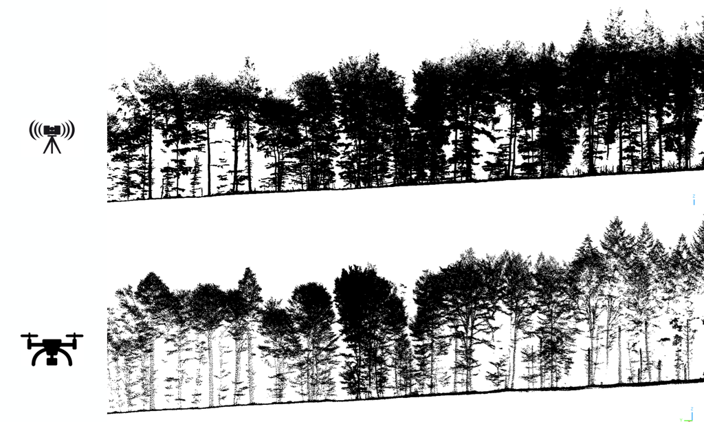

## Load Packages, paths, etc…

```r
#install.packages(c("lidR","terra", "dplyr", "viridis))
library(lidR)
library(viridis)
library(dplyr)
library(terra)
```

## Compare the drone-based inventory with the field inventory

### load the data

UAV-based point clouds with AI-based tree segmentation

```r
pc_uav <- readLAS("uav_pointcloud_red.las")
pc_uav
```

```
class        : LAS (v1.4 format 6)
memory       : 326.8 Mb
extent       : 416648.3, 416838.9, 5346560, 5346871 (xmin, xmax, ymin, ymax)
coord. ref.  : NA
area         : 41168 units²
points       : 6.12 million points
density      : 148.66 points/units²
```

TLS-based point clouds with AI-based tree segmentation

```r
pc_tls <- readLAS("tls_pointcloud_red.las")
pc_tls
```

```
class        : LAS (v1.4 format 6)
memory       : 294.8 Mb
extent       : 416648.2, 416839, 5346560, 5346871 (xmin, xmax, ymin, ymax)
coord. ref.  : NA
area         : 41140 units²
points       : 5.52 million points
density      : 134.17 points/units²
```

Load the tree inventory data from ECOSENSE (full inventory).  
*.gpkg stands for geopackage format. We can load that in R using terra as SpatVector object.

```r
tree_inv <- vect("tree_inventory_final2.gpkg")
```

```r
head(tree_inv)
```

```
  species tls_name      tls_TH     tls_DBH       tls_X       tls_Y
1      BE    T2792 27.28962149 0.088146948  416700.687 5346611.676
2      BE    T2756 27.65825122  0.16474044  416698.162 5346611.911
3      BE    T2763 26.53824404 0.136313621 416699.4069 5346613.154
4      BE    T2793 28.58093068 0.363458403 416704.5793 5346614.498
5      BE    T2816 28.73643552 0.387836247 416703.9667 5346609.953
6      BE                 <NA>        <NA>        <NA>        <NA>
      tls_Longitude      tls_Latitude odk_add_tree.loop_time
1 7.877502550380541 48.26723262917562   2024-11-26T11:23:27Z
2 7.877468485304306 48.26723441090238   2024-11-26T11:36:16Z
3 7.877485012699943 48.26724575547465   2024-11-26T11:41:34Z
4 7.877554434593113 48.26725852509873   2024-11-26T11:43:50Z
5 7.877547076487936 48.26721756208074   2024-11-26T11:46:38Z
6              <NA>              <NA>   2024-11-26T11:48:11Z
  odk_add_tree.plot_id odk_add_tree.tree_id odk_add_tree.new_tree
```

[output cut: 83 more lines]

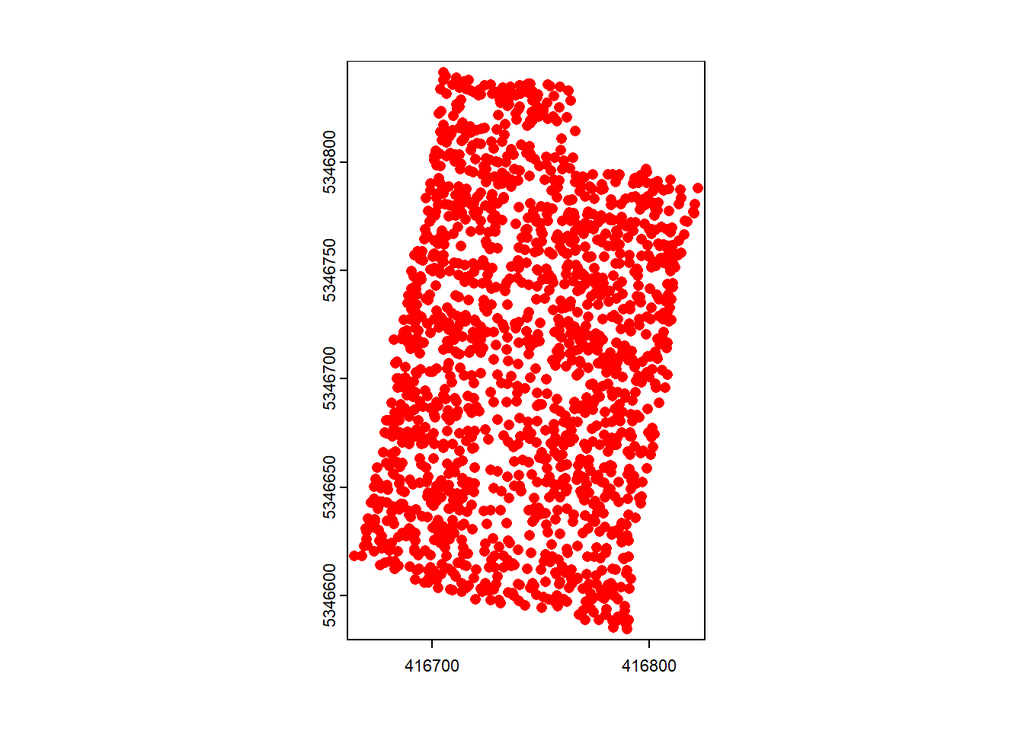

```r
plot(tree_inv, col = "red")
```

```r
# please ignore
#tree_inv_spec <- read.csv("lookup_odk2.csv", sep = ",", header = T)
#tree_inv2 <- merge(tree_inv, tree_inv_spec, by.x = "species", by.y = "abbr")
#writeVector(tree_inv2, "D:/output_file.gpkg", filetype = "GPKG")
```

### Visually compare TLS & UAV-based inventory

```r
col <- sample(viridis(2070, option = "mako"))
p <- plot(pc_uav, color = "PredInstance", pal = col, legend = F, axis = T, nbreaks = length(col))
```

```r
col <- sample(viridis(2070, option = "mako"))
p <- plot(pc_tls, color = "PredInstance", pal = col, legend = F, axis = T, nbreaks = length(col))
```

### Inspect the inventory data

### Compare UAV-based segmentation result to full inventory

Normalize point cloud on Z-axis

```r
mycsf <- csf(TRUE, 1, 1, time_step = 1)
pc_uav <- classify_ground(pc_uav, mycsf)
pc_uav_n <- normalize_height(pc_uav, knnidw())
```

[output not shown]

```r
plot(pc_uav_n, axis = T)
```

Cut a transect for stem extraction

```r
pc_uav_n_trans <- filter_poi(pc_uav_n, Z >= 0.1 & Z <= 4)
col <- sample(viridis(2070, option = "mako"))
```

```r
plot(pc_uav_n_trans, color = "PredInstance", pal = col, legend = F, axis = T, nbreaks = length(col))
```

Derive the centroids for stems

```r
# Calculate centroids for each instance
centroids_uav <- pc_uav_n_trans@data %>%
  group_by(PredInstance) %>%
  summarize(
    X = mean(X),
    Y = mean(Y),
    Z = 0,
    species = as.integer(names(which.max(table(species_id)))),
    .groups = "drop"  # Avoid unnecessary grouping in the result
  )

# Print centroids
print(centroids_uav)
```

```
# A tibble: 1,751 × 5
   PredInstance       X        Y     Z species
          <int>   <dbl>    <dbl> <dbl>   <int>
 1            0 416745. 5346740.     0       0
 2            1 416779. 5346568.     0      19
 3            2 416772. 5346570.     0      10
 4            5 416784. 5346569.     0      10
 5            6 416784. 5346571.     0      10
 6            7 416780. 5346569.     0      10
 7            8 416787. 5346566.     0      25
 8            9 416796. 5346561.     0      19
 9           10 416790. 5346563.     0      10
10           12 416797. 5346568.     0      10
# ℹ 1,741 more rows
```

Convert the centroids to a proper geospatial vector format (SpatVector)

```r
centroids_uav_sv <- vect(centroids_uav, geom = c("X", "Y"), crs = "EPSG:32632")
```

Visually compare the UAV-based centroids with the inventory data

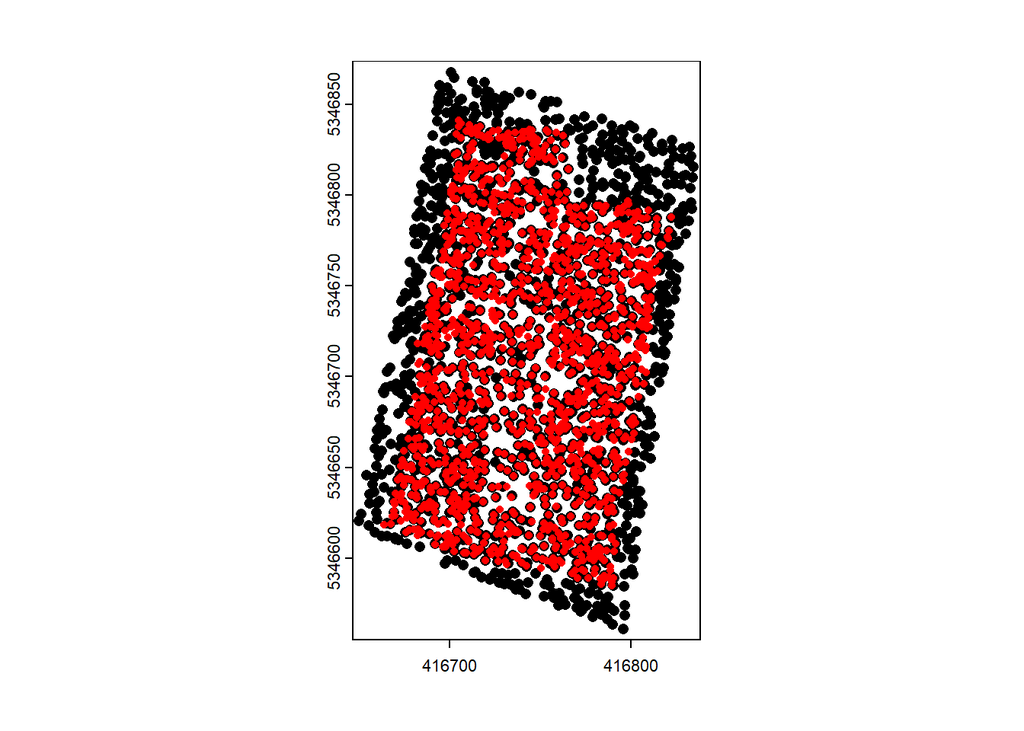

```r
plot(centroids_uav_sv)
points(tree_inv, col = "red")
```

Quantitatively compare the UAV-based centroids with the inventory data

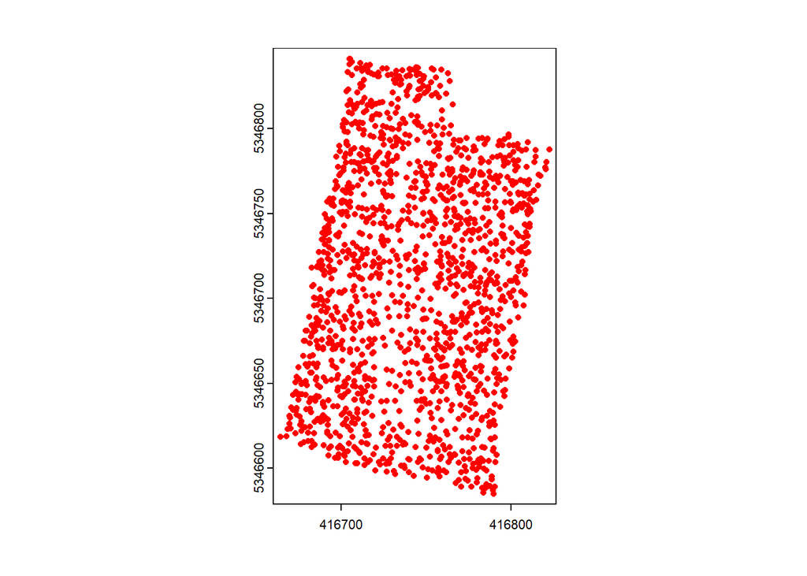

```r
buffer_tree_inv <- buffer(tree_inv, width = 1)
plot(buffer_tree_inv)
points(tree_inv, col = "red")
```

```r
matches_uav <- intersect(buffer_tree_inv, centroids_uav_sv)
```

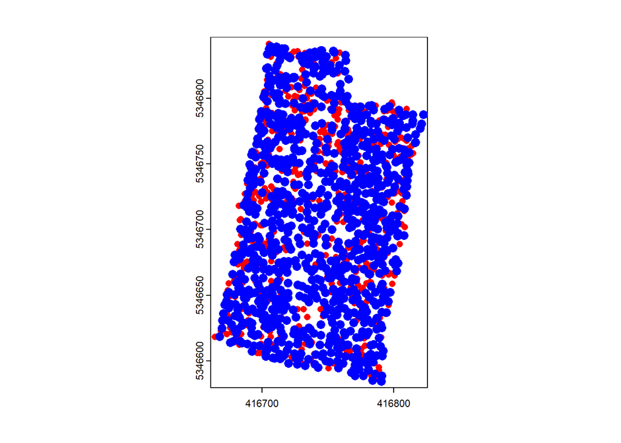

```r
plot(tree_inv, col = "red")
points(matches_uav, col = "blue", cex = 1.3)
```

```r
nrow(matches_uav)/nrow(tree_inv)*100
```

```
[1] 66.16786
```

Is there a systematic bias in the detection?

```r
unmatched_uav <- buffer_tree_inv[!(buffer_tree_inv$TreeID %in% matches_uav$TreeID), ]
```

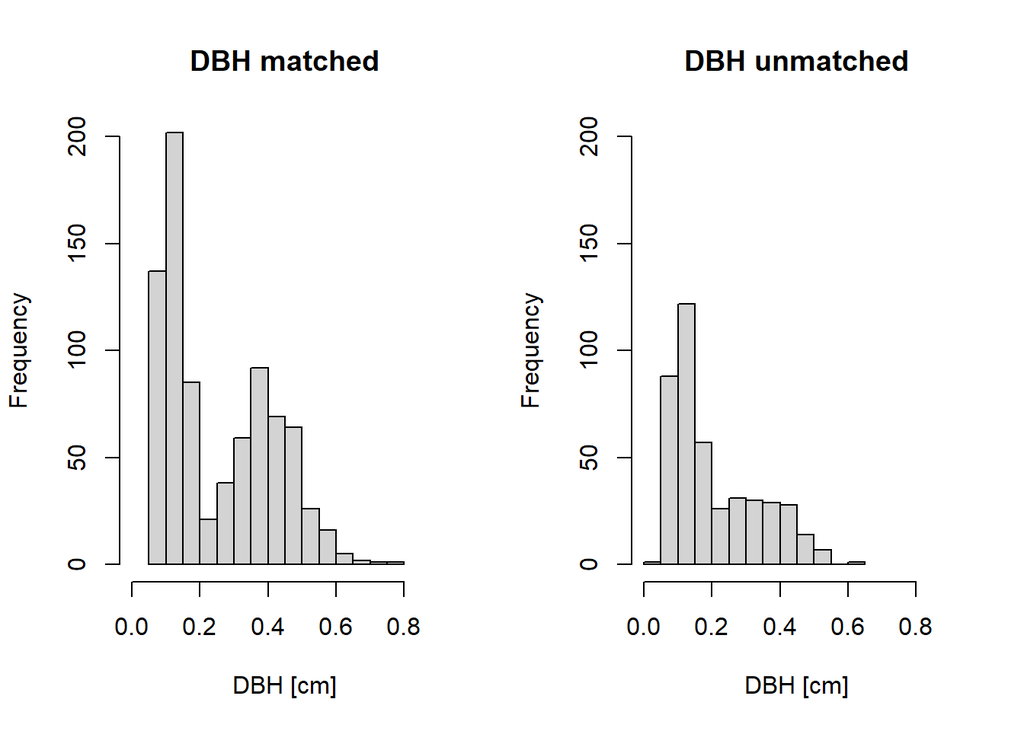

```r
par(mfrow = c(1,2))
hist(as.numeric(matches_uav$tls_DBH),
     xlim = c(0,0.9),
     ylim=c(0,200),
     main = "DBH matched",
     xlab = "DBH [cm]")
hist(as.numeric(unmatched_uav$tls_DBH),
     xlim = c(0,0.9),
     ylim=c(0,200),
     main = "DBH unmatched",
     xlab = "DBH [cm]")
```

## TLS analysis

Same procedure as for the UAV data. First, we normalize the point cloud…

```r
mycsf <- csf(TRUE, 1, 1, time_step = 1)
pc_tls <- classify_ground(pc_tls, mycsf)
pc_tls_n <- normalize_height(pc_tls, knnidw())
```

[output not shown]

```r
plot(pc_tls_n, axis = T)
```

… create a transect of stems…

```r
pc_tls_n_trans <- filter_poi(pc_tls_n, Z >= 0.1 & Z <= 4)
col <- sample(viridis(2070, option = "mako"))
```

```r
plot(pc_tls_n_trans, color = "PredInstance", pal = col, legend = F, axis = T, nbreaks = length(col))
```

… find the centroids of the stems.

```r
# Calculate centroids for each instance
centroids_tls <- pc_tls_n_trans@data %>%
  group_by(PredInstance) %>%
  summarize(
    X = mean(X),
    Y = mean(Y),
    Z = 0,
    species = as.integer(names(which.max(table(species_id)))),
    .groups = "drop"  # Avoid unnecessary grouping in the result
  )

# Print centroids
print(centroids_tls)
```

```
# A tibble: 2,093 × 5
   PredInstance       X        Y     Z species
          <int>   <dbl>    <dbl> <dbl>   <int>
 1            0 416740. 5346724.     0       0
 2          797 416718. 5346589.     0      10
 3          798 416723. 5346588.     0      10
 4          802 416727. 5346587.     0      10
 5          803 416735. 5346586.     0      10
 6          807 416736. 5346582.     0      10
 7          808 416730. 5346586.     0      10
 8          809 416737. 5346583.     0       3
 9          810 416734. 5346583.     0      10
10          811 416742. 5346580.     0       3
# ℹ 2,083 more rows
```

Let´s compare the result to the inventory data:

```r
centroids_tls_sv <- vect(centroids_tls, geom = c("X", "Y"), crs = "EPSG:32632")
```

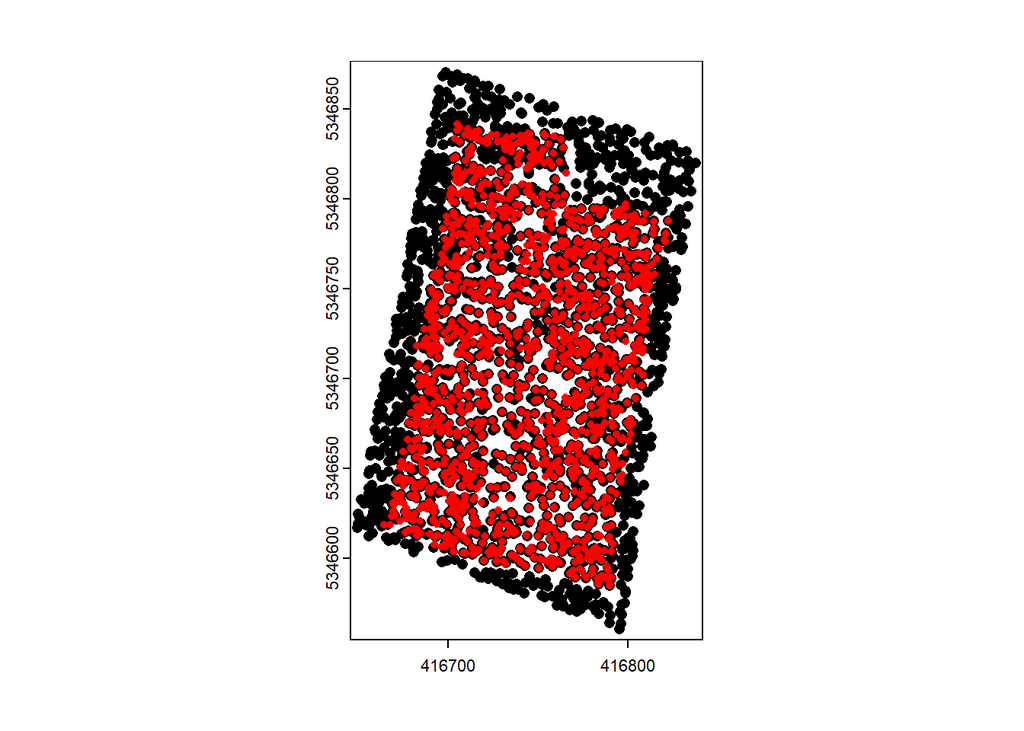

```r
plot(centroids_tls_sv)
points(tree_inv, col = "red")
```

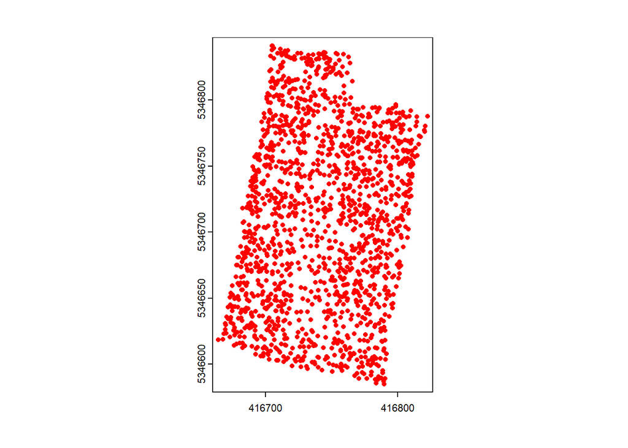

```r
buffer_tree_inv <- buffer(tree_inv, width = 1)
plot(buffer_tree_inv)
points(tree_inv, col = "red")
```

```r
matches_tls <- intersect(centroids_tls_sv, buffer_tree_inv)
```

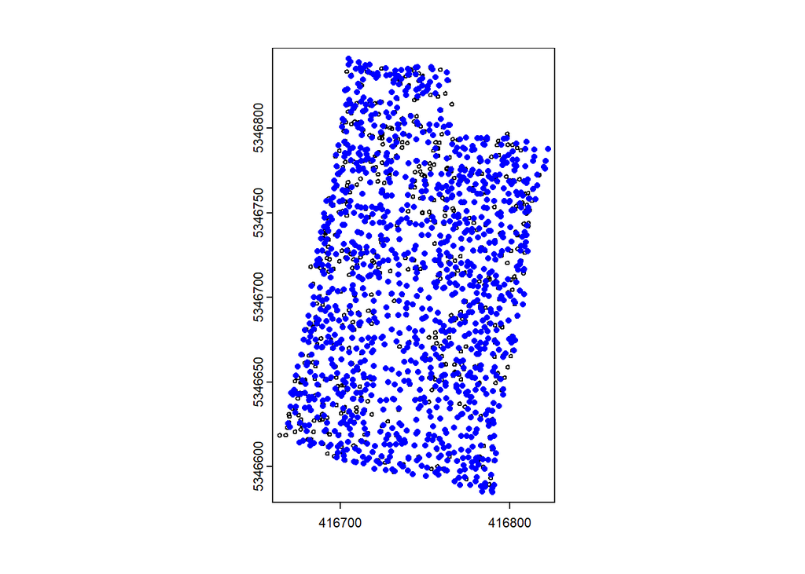

```r
plot(buffer_tree_inv)
points(matches_tls, col = "blue")
```

```r
nrow(matches_tls)/nrow(tree_inv)*100
```

```
[1] 81.52245
```

## TLS & UAV tree height comparison

Extract maximum Z value per instance:

```r
# Find the highest point for each instance
uav_tree_heights <- pc_uav_n@data %>%
  group_by(PredInstance) %>%
  slice_max(Z, n = 1) %>%  # Get the row with the maximum Z value for each instance
  ungroup()

uav_tree_heights <- uav_tree_heights[, c("X", "Y", "Z", "PredInstance")]

# View the results
print(uav_tree_heights)
```

```
# A tibble: 2,161 × 4
         X        Y     Z PredInstance
     <dbl>    <dbl> <dbl>        <int>
 1 416754. 5346752.  46.6            0
 2 416778. 5346567.  28.4            1
 3 416772. 5346569.  24.7            2
 4 416778. 5346569.  28.6            4
 5 416788. 5346570   13.1            5
 6 416788. 5346571.  30.4            6
 7 416780. 5346570.  29.2            7
 8 416788. 5346566.  34.2            8
 9 416796. 5346561.  27.0            9
10 416791. 5346562.  26.7           10
# ℹ 2,151 more rows
```

```r
# Find the highest point for each instance
tls_tree_heights <- pc_tls_n@data %>%
  group_by(PredInstance) %>%
  slice_max(Z, n = 1) %>%  # Get the row with the maximum Z value for each instance
  ungroup()

tls_tree_heights <- tls_tree_heights[, c("X", "Y", "Z", "PredInstance")]

# View the results
print(tls_tree_heights)
```

```
# A tibble: 2,578 × 4
         X        Y     Z PredInstance
     <dbl>    <dbl> <dbl>        <int>
 1 416750. 5346755.  37.9            0
 2 416711. 5346592.  15.7          669
 3 416760. 5346574.  19.0          700
 4 416756. 5346575.  18.3          703
 5 416768. 5346570.  24.4          709
 6 416785. 5346564.  27.6          717
 7 416699. 5346597.  11.8          787
 8 416692. 5346599.  18.6          789
 9 416716. 5346590.  28.7          797
10 416719. 5346589.  26.4          798
# ℹ 2,568 more rows
```

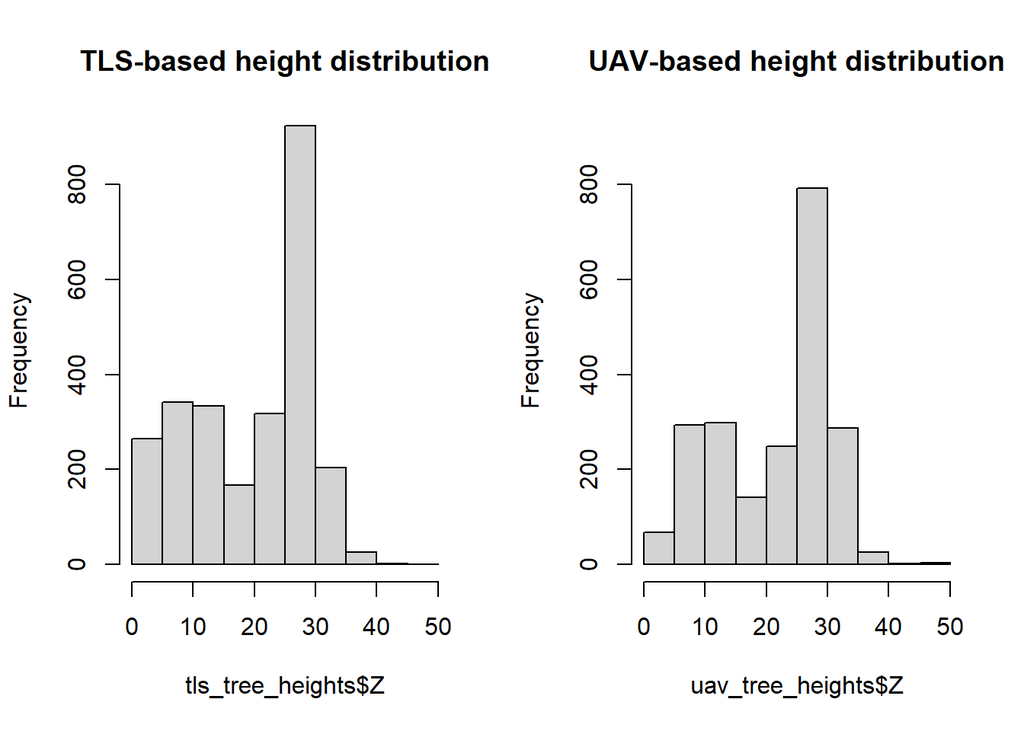

```r
par(mfrow = c(1,2))
hist(tls_tree_heights$Z, ylim = c(0,900), main = "TLS-based height distribution")
hist(uav_tree_heights$Z, ylim = c(0,900), main = "UAV-based height distribution")
```

```r
paste("number TLS-based trees: ", nrow(tls_tree_heights))
```

```
[1] "number TLS-based trees:  2578"
```

```r
print("TLS-based tree heights")
```

```
[1] "TLS-based tree heights"
```

```r
summary(tls_tree_heights$Z)
```

```
   Min. 1st Qu.  Median    Mean 3rd Qu.    Max.
   0.00   10.56   23.44   19.51   27.96   46.18
```

```r
paste("number UAV-based trees: ", nrow(uav_tree_heights))
```

```
[1] "number UAV-based trees:  2161"
```

```r
print("UAV-based tree heights")
```

```
[1] "UAV-based tree heights"
```

```r
summary(uav_tree_heights$Z)
```

```
   Min. 1st Qu.  Median    Mean 3rd Qu.    Max.
  2.065  12.636  25.462  21.584  28.962  48.443
```

When looking at the transects … can you explain the results?

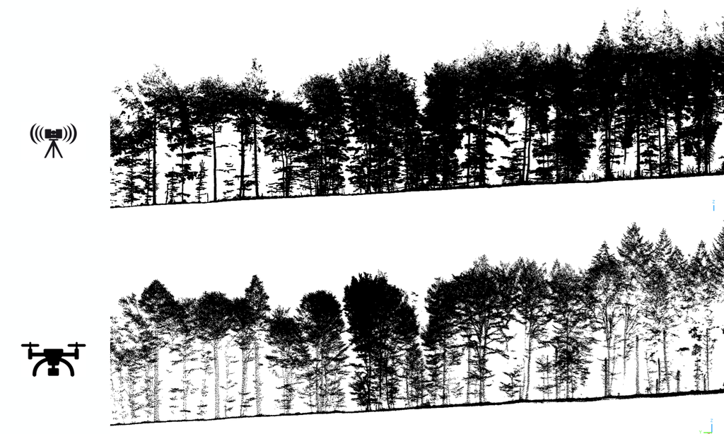

## AI-based Species identification

We will test `DetailView` from Julian Frey: https://github.com/JulFrey/DetailView

You can read on the details here: [Puliti, S., Lines, E. R., Müllerová, J., Frey, J., Schindler, Z., Straker, A., ... & Astrup, R. (2024). Benchmarking tree species classification from proximally-sensed laser scanning data: introducing the FOR-species20K dataset. *arXiv preprint arXiv:2408.06507*.](https://arxiv.org/abs/2408.06507)

Currently, DetailView is one of the most accurate tree species classifiaction modelds for LiDAR data:

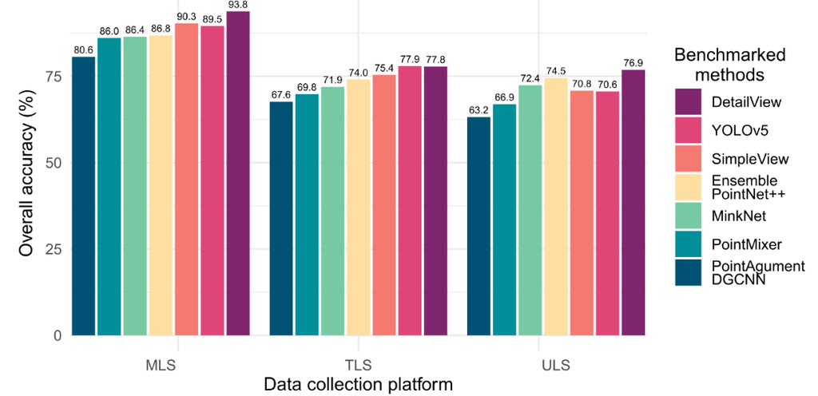

Let´s first have look at the reality (forest inventory data of ECOSENSE):

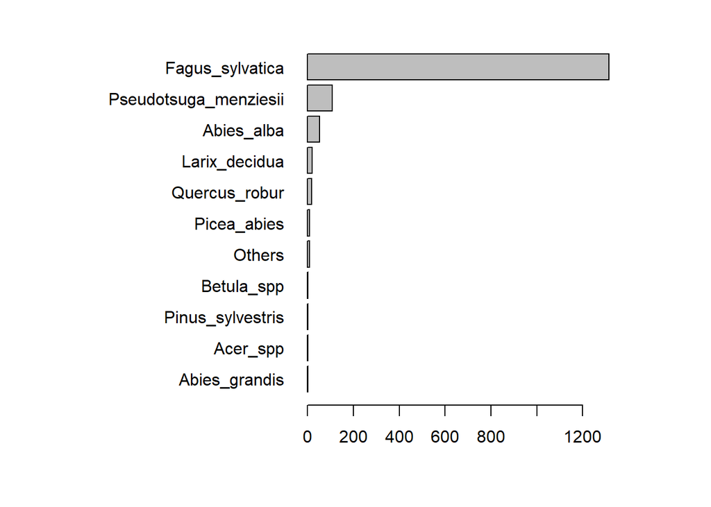

```r
par(mar = c(5, 15, 2, 5))
barplot(sort(table(tree_inv$species_name)), las = 1, horiz = T)
```

The UAV- and TLS-based predictions come in species-codes, not species names. So we first load a look up table to attach (merge) the actual names to our data:

```r
species_ai <- read.csv("lookup_ai.csv")
```

… attach the species name to the point clouds….

```r
pc_tls@data <- merge(pc_tls@data, species_ai, by = "species_id", all.x = TRUE)
pc_uav@data <- merge(pc_uav@data, species_ai, by = "species_id", all.x = TRUE)
```

… and to the extract stem coordinates (centroids):

```r
centroids_tls_sv2 <- merge(centroids_tls_sv , species_ai, by.x ="species", by.y = "species_id", all.x = TRUE)
centroids_uav_sv2 <- merge(centroids_uav_sv , species_ai, by.x ="species", by.y = "species_id", all.x = TRUE)
```

### Visual comparison of the species classification

```r
p <- plot(pc_tls, color = "species_id", legend = T, axis = T)
p <- plot(pc_uav, color = "species_id", legend = T, axis = T)
```

Okay, the results “look” already quite different. Let´s check the stats:

```r
uav_n_spec <- pc_uav@data %>%
  as.data.frame() %>%
  group_by(species) %>%
  summarise(number_of_instances = n_distinct(PredInstance)) %>%
  arrange(desc(number_of_instances))

uav_n_spec
```

```
# A tibble: 15 × 2
   species               number_of_instances
   <chr>                               <int>
 1 Fagus_sylvatica                      1110
 2 Betula_pendula                        408
 3 Pinus_radiata                         185
 4 Carpinus_betulus                       91
 5 Pseudotsuga_menziesii                  83
 6 Quercus_rubra                          77
 7 Pinus_sylvestris                       68
 8 Picea_abies                            63
 9 Acer_pseudoplatanus                    34
10 Acer_saccharum                         16
11 Abies_alba                             12
12 Acer_campestre                          6
13 Quercus_petraea                         4
14 Larix_decidua                           3
15 Quercus_robur                           1
```

```r
tls_n_spec <- pc_tls@data %>%
  as.data.frame() %>%
  group_by(species) %>%
  summarise(number_of_instances = n_distinct(PredInstance)) %>%
  arrange(desc(number_of_instances))

tls_n_spec
```

```
# A tibble: 23 × 2
   species               number_of_instances
   <chr>                               <int>
 1 Fagus_sylvatica                      1024
 2 Acer_saccharum                        626
 3 Pseudotsuga_menziesii                 196
 4 Abies_alba                             95
 5 Picea_abies                            92
 6 Pinus_sylvestris                       56
 7 Quercus_robur                          52
 8 Corylus_avellana                       46
 9 Betula_pendula                         45
10 Carpinus_betulus                       43
# ℹ 13 more rows
```

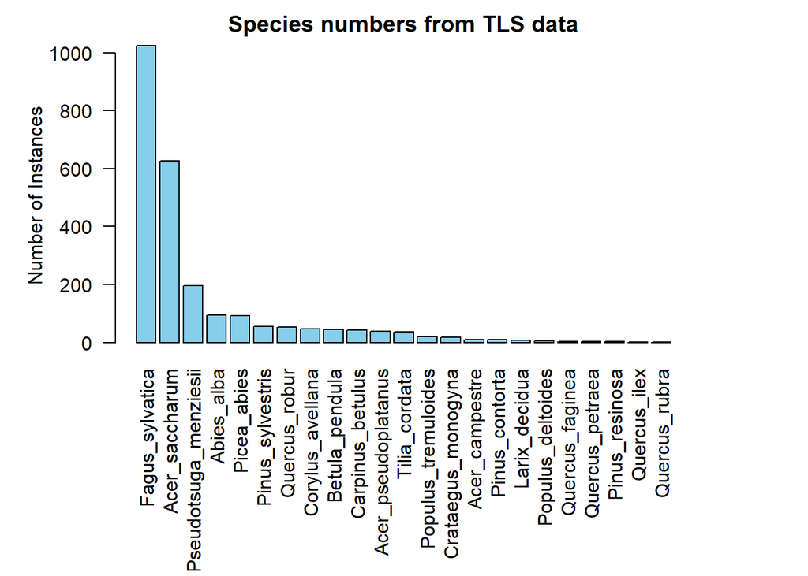

```r
par(mar = c(10, 5, 2, 5))

# Convert species to a named vector
species_counts <- setNames(tls_n_spec$number_of_instances, tls_n_spec$species)

# Create the barplot
barplot(species_counts,
        las = 2,              # Rotate axis labels for readability
        col = "skyblue",      # Add some color
        main = "Species numbers from TLS data",  # Add a title
        ylab = "Number of Instances")  # Add Y-axis label
```

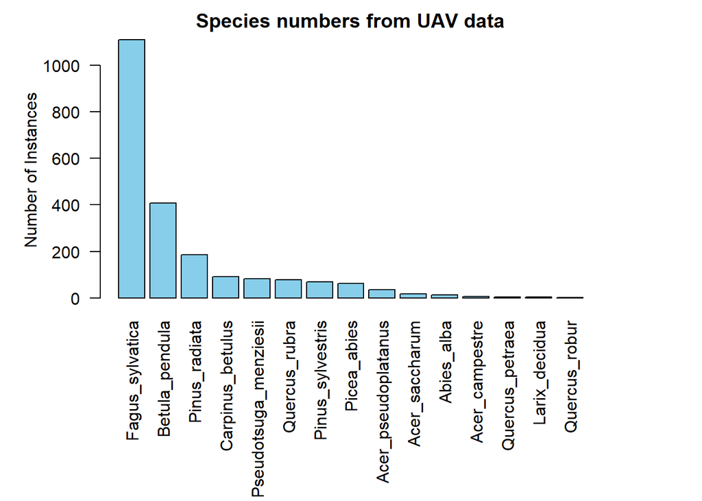

```r
par(mar = c(10, 5, 2, 5))

# Convert species to a named vector
species_counts <- setNames(uav_n_spec$number_of_instances, uav_n_spec$species)

# Create the barplot
barplot(species_counts,
        las = 2,              # Rotate axis labels for readability
        col = "skyblue",      # Add some color
        main = "Species numbers from UAV data",  # Add a title
        ylab = "Number of Instances")  # Add Y-axis label
```

### Compare the tree species distribution among datasets:

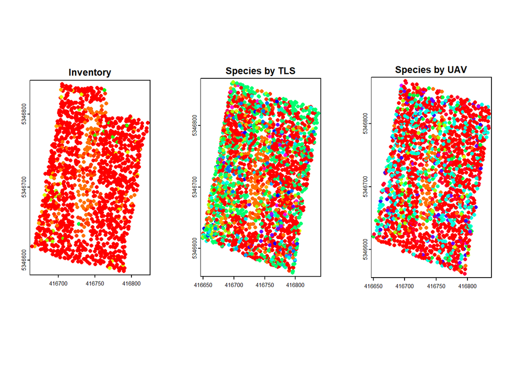

```r
# Extract unique species across all SpatVectors
all_species <- unique(c(tree_inv$species_name, centroids_tls_sv2$species.y, centroids_uav_sv2$species.y))

tree_inv$species.y <- tree_inv$species_name

# Create a color palette for all species
species_colors <- setNames(rainbow(length(all_species)), all_species)

# Function to assign colors based on species
get_colors <- function(spatvector, color_mapping) {
  color_mapping[spatvector$species.y]
}

# Adjust layout to include space for the legend
par(mfrow = c(1, 3), mar = c(4, 4, 2, 1))  # 2x2 grid, adjust margins as needed


plot(tree_inv,
     col = get_colors(tree_inv, species_colors),
     main = "Inventory",
     legend = FALSE)

plot(centroids_tls_sv2,
     col = get_colors(centroids_tls_sv2, species_colors),
     main = "Species by TLS",
     legend = FALSE)

plot(centroids_uav_sv2,
     col = get_colors(centroids_uav_sv2, species_colors),
     main = "Species by UAV",
     legend = FALSE)
```

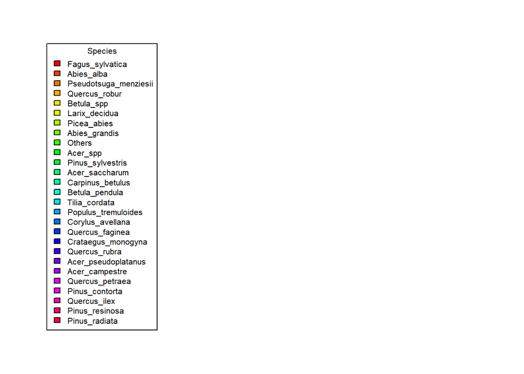

```r
par(mfrow = c(1, 3), mar = c(1, 4, 1, 1))
plot.new()  # Create an empty plot for the legend
legend("center", legend = names(species_colors), fill = species_colors, title = "Species")
```

### How could we potentially improve the tree species classification?

### Can we trust UAV-based or TLS-based inventories?

### What are related advantages or disadvantages?